# Potential Outcomes in R

## Potential Outcomes

$$ATE = E[Y_i^1 - Y_i^0]$$

#### Task 1: Simulate 100,000 student test scores with a mean of 100 and standard deviation of 25. Test scores should not be lower than 0 or greater than 200. Then, plot the distribution. (Hint: Look up the R stats function rnorm.)

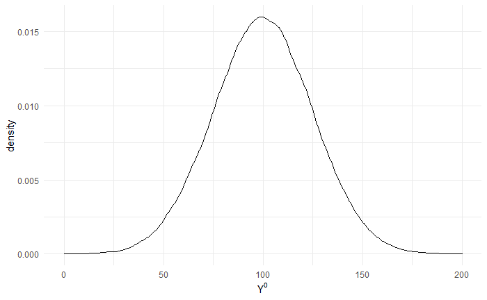

#### Task 2: Imagine another universe where the only difference is the students from Task 1 had a treatment which boosted their performance on the test. Add a mean shift of 5 with a standard deviation of 2 to all the test scores from Task 1. Test scores should still not be lower than 0 or greater than 200. Then, plot both distributions together.

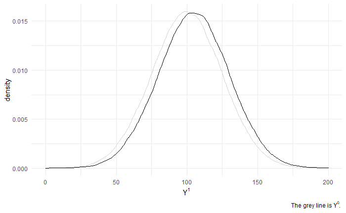

```r
Y1 <- (Y0 + rnorm(N, 5, 2)) %>% constrain(0, 200)

ggplot() +
  geom_density(aes(x=Y0), color="lightgrey") +
  geom_density(aes(x=Y1)) +
  labs(x=TeX("$Y^1$"), caption=TeX("The grey line is $Y^0$."))
```

#### Task 3: Calculate the true treatment effect for each student. Then, calculate the true average treatment effect for the population. Plot the treatment effect distribution and the average treatment effect.

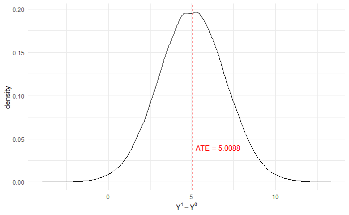

Unfortunately, $Y^0$ and $Y^1$ can never be observed for the same individual. So, we have to estimate. Since,

$$\begin{align}
ATE &= E[Y_i^1 - Y_i^0] \\
&= E[Y^1] - E[Y^0]
\end{align}$$
the outcome under treatment and control can be estimated separately from samples of the population.

$$E[Y^1|S=1] = E[Y^1] \\
E[Y^0|S=2] = E[Y^0]$$
The estimated ATE then is given by:

$$\begin{align}
ATE &= E[Y_i^1 - Y_i^0] \\
&= E[Y^1] - E[Y^0] \\
&= E[Y^1|S=1] - E[Y^0|S=2]
\end{align}$$

```r
n <- 200

population <- data.frame(Y0, Y1, TE)
sample <- slice_sample(population, n=n)

data.frame(
  variable = c("Y0", "Y1"),
  pop_mean = c(mean(population$Y0), mean(population$Y1)),
  sample_mean = c(mean(sample$Y0), mean(sample$Y1)),
  est_se = c(sd(sample$Y0)/sqrt(n), sd(sample$Y1)/sqrt(n)),
  actual_se = c(sd(population$Y0)/sqrt(n), sd(population$Y1)/sqrt(n))
)
```

| variable | pop_mean | sample_mean | est_se | actual_se |
| --- | --- | --- | --- | --- |
| Y0 | 99.91667 | 100.3427 | 1.748442 | 1.768663 |
| Y1 | 104.92544 | 105.3277 | 1.751336 | 1.774760 |

$$se = \frac{sd}{\sqrt{n}}$$
What is the standard error?

#### Task 4: Demonstrate that the standard error is the standard deviation of the mean upon repeated sampling.

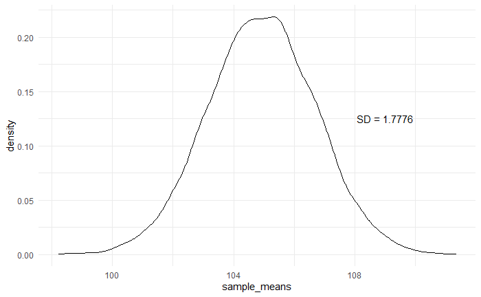

```r
n <- 200

sample_means <- sapply(1:10000, function(i) {
  sample <- slice_sample(population, n=n)
  sample_mean <- mean(sample$Y1)

  return(sample_mean)
})

ggplot() +
  geom_density(aes(x = sample_means)) +
  annotate("text", 109, 0.125, label=paste0("SD = ", round(sd(sample_means), 4)))
```

$$ATE = E[Y_i^1 - Y_i^0] = E[Y^1] - E[Y^0] = E[Y^1|S=1] - E[Y^0|S=2]$$

```r
sample_1 <- slice_sample(population, n=n)
sample_2 <- slice_sample(population, n=n)

t.test(sample_1$Y1, sample_2$Y0, paired=T, var.equal=T)
```

```
    Paired t-test

data:  sample_1$Y1 and sample_2$Y0
t = 0.77284, df = 199, p-value = 0.4405
alternative hypothesis: true difference in means is not equal to 0
95 percent confidence interval:
 -3.139887  7.187217
sample estimates:
mean of the differences
               2.023665
```

```r
df <- data.frame(
  Y = c(sample_1$Y1, sample_2$Y0),
  D = rep(c(1, 0), each=n)
)

lm(Y ~ D, data=df) %>% summary
```

```
Call:
lm(formula = Y ~ D, data = df)

Residuals:
    Min      1Q  Median      3Q     Max
-89.306 -17.599  -0.612  17.805  89.005

Coefficients:
            Estimate Std. Error t value Pr(>|t|)
(Intercept)  101.932      1.897  53.729   <2e-16 ***
D              2.024      2.683   0.754    0.451
---
Signif. codes:  0 ‘***’ 0.001 ‘**’ 0.01 ‘*’ 0.05 ‘.’ 0.1 ‘ ’ 1

Residual standard error: 26.83 on 398 degrees of freedom
Multiple R-squared:  0.001427,  Adjusted R-squared:  -0.001082
F-statistic: 0.5689 on 1 and 398 DF,  p-value: 0.4511
```

That’s not actually how an RCT is done.

$$ATE = E[Y_i^1 - Y_i^0] = E[Y^1] - E[Y^0] = E[Y^1|S=1, D=1] - E[Y^0|S=1, D=0]$$

```r
sample_RCT <- slice_sample(population, n=n*2)

sample_RCT <- sample_RCT %>%
  mutate(
    D = ifelse(row_number() <= n, 1, 0),
    Y = ifelse(D == 1, Y1, Y0)
    )

t.test(sample_RCT[which(sample_RCT$D == 1), "Y"], sample_RCT[which(sample_RCT$D == 0), "Y"], paired=T, var.equal=T)
```

```
    Paired t-test

data:  sample_RCT[which(sample_RCT$D == 1), "Y"] and sample_RCT[which(sample_RCT$D == 0), "Y"]
t = 1.8883, df = 199, p-value = 0.06045
alternative hypothesis: true difference in means is not equal to 0
95 percent confidence interval:
 -0.2191017 10.1056073
sample estimates:
mean of the differences
               4.943253
```

```r
sample_RCT %>%
  lm(Y ~ D, data=.) %>% summary
```

```
Call:
lm(formula = Y ~ D, data = .)

Residuals:
    Min      1Q  Median      3Q     Max
-91.749 -15.455   1.065  15.840  77.325

Coefficients:
            Estimate Std. Error t value Pr(>|t|)
(Intercept)   99.206      1.807  54.902   <2e-16 ***
D              4.943      2.555   1.934   0.0538 .
---
Signif. codes:  0 ‘***’ 0.001 ‘**’ 0.01 ‘*’ 0.05 ‘.’ 0.1 ‘ ’ 1

Residual standard error: 25.55 on 398 degrees of freedom
Multiple R-squared:  0.009314,  Adjusted R-squared:  0.006825
F-statistic: 3.742 on 1 and 398 DF,  p-value: 0.05377
```

These aren’t actually good estimators for an RCT because they ignore the design. Randomization in an RCT is simple random sampling from a finite sample not an infinite population.

### Randomization test

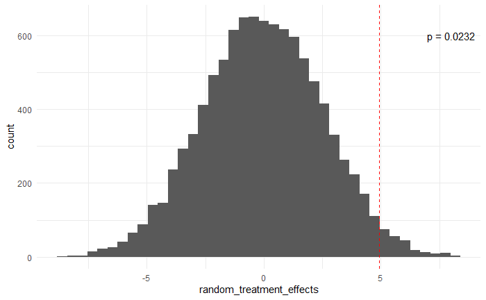